# Защита персональных данных клиентов

# Содержание

## Описание проекта

Вам нужно защитить данные клиентов страховой компании «Хоть потоп». Разработайте такой метод преобразования данных, чтобы по ним было сложно восстановить персональную информацию. Обоснуйте корректность его работы.

Нужно защитить данные, чтобы при преобразовании качество моделей машинного обучения не ухудшилось. Подбирать наилучшую модель не требуется.

### Инструкция по выполнению проекта

1. Загрузите и изучите данные.
2. Ответьте на вопрос и обоснуйте решение. Признаки умножают на обратимую матрицу. Изменится ли качество линейной регрессии? (Её можно обучить заново.)

   а) Изменится. Приведите примеры матриц. б) Не изменится. Укажите, как связаны параметры линейной регрессии в исходной задаче и в преобразованной.
3. Предложите алгоритм преобразования данных для решения задачи. Обоснуйте, почему качество линейной регрессии не поменяется.
4. Запрограммируйте этот алгоритм, применив матричные операции. Проверьте, что качество линейной регрессии из sklearn не отличается до и после преобразования. Примените метрику R2.
5. **Описание данных**
   - Набор данных находится в файле /datasets/insurance.csv
   - **Признаки**: пол, возраст и зарплата застрахованного, количество членов его семьи.
   - **Целевой признак**: количество страховых выплат клиенту за последние 5 лет.

## Подготовка данных

```python
# Установка используемых в проекте пакетов
!pip install scikit-learn==1.1.3 phik
```

```python
# Импорт стандартных библиотек
import pandas as pd
import numpy as np
import seaborn as sns
import matplotlib.pyplot as plt
from sklearn.model_selection import train_test_split
from sklearn.linear_model import LinearRegression

# Импорт сторонних библиотек
from phik.report import plot_correlation_matrix
```

**Глобальные переменные**

```python
RANDOM_STATE = np.random.RandomState(654)
```

### Настройки модулей

```python
# Setting pandas
pd.set_option('display.max_columns', None)
pd.options.display.float_format = '{:,.2f}'.format

import warnings
warnings.filterwarnings("ignore")

from IPython.core.display import display, HTML
display(HTML("<style>.container { width:90% !important; }</style>"))
```

### Загрузка данных

```python
# Read CSV
try:
    df = pd.read_csv(f'../datasets/insurance.csv', sep=',')
    print('DataSets загружен локально')
except:
    df = pd.read_csv(f'https://.../insurance.csv', sep=',') # Скрыто по правилам Yandex
    print('DataSets загружен с облака')
```

```
DataSets загружен локально
```

### Разведочный анализ данных (Exploratory Data Analysis, EDA)

```
Первые 5 строк датасета:
```

|  | Пол | Возраст | Зарплата | Члены семьи | Страховые выплаты |
| --- | --- | --- | --- | --- | --- |
| 3320 | 0 | 19.00 | 35,000.00 | 6 | 0 |
| 4460 | 1 | 23.00 | 34,800.00 | 2 | 0 |
| 1249 | 1 | 41.00 | 36,000.00 | 3 | 0 |
| 637 | 1 | 41.00 | 30,900.00 | 3 | 0 |
| 3866 | 1 | 32.00 | 23,100.00 | 1 | 0 |

```
________________________

Пропуски в датасете:
```

```
Пол                 0.00
Возраст             0.00
Зарплата            0.00
Члены семьи         0.00
Страховые выплаты   0.00
dtype: float64
```

```
________________________

Дубликаты в датасете, учитывая индексы: 153
________________________

Типы столбцов датафрейма:
```

```
Пол                    int64
Возраст              float64
Зарплата             float64
Члены семьи            int64
Страховые выплаты      int64
dtype: object
```

```
________________________

Describe датасета:
```

|  | Пол | Возраст | Зарплата | Члены семьи | Страховые выплаты |
| --- | --- | --- | --- | --- | --- |
| count | 5,000.00 | 5,000.00 | 5,000.00 | 5,000.00 | 5,000.00 |
| mean | 0.50 | 30.95 | 39,916.36 | 1.19 | 0.15 |
| std | 0.50 | 8.44 | 9,900.08 | 1.09 | 0.46 |
| min | 0.00 | 18.00 | 5,300.00 | 0.00 | 0.00 |
| 25% | 0.00 | 24.00 | 33,300.00 | 0.00 | 0.00 |
| 50% | 0.00 | 30.00 | 40,200.00 | 1.00 | 0.00 |
| 75% | 1.00 | 37.00 | 46,600.00 | 2.00 | 0.00 |
| max | 1.00 | 65.00 | 79,000.00 | 6.00 | 5.00 |

```
Уникальные значения признаков:

"Пол": 2
"Возраст": 46
"Зарплата": 524
"Члены семьи": 7
"Страховые выплаты": 6
____________________________________
```

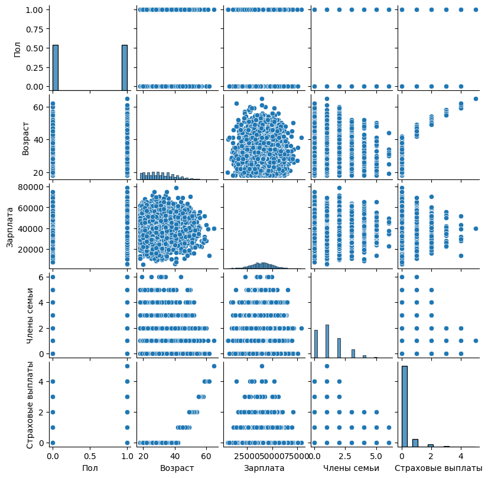

```python
# Отображение первых 5 строк датасета
print('Первые 5 строк датасета:\n')
display(df.sample(5))
print('________________________\n')

# Поиск пропусков в датасете
print('Пропуски в датасете:')
display(df.isna().mean())
print('________________________\n')

# Поиск дубликатов, учитывая индексы
print('Дубликаты в датасете, учитывая индексы:', df.duplicated().sum())
print('________________________\n')

# Вывод типов столбцов датафрейма
print('Типы столбцов датафрейма:')
display(df.dtypes)
print('________________________\n')

# Вывод описательной статистики датасета
print('Describe датасета:\n')
display(df.describe(include='all'))

# Вывод уникальных значений для каждого признака
print('Уникальные значения признаков:\n')
for column in df:
    print(f'"{column}": {df[column].nunique()}')

print('____________________________________\n\n\n')

# Создание pairplot для каждого признака
sns.pairplot(df)
plt.gcf().set_size_inches(8, 8)
plt.show()
```

```python
total_records = len(df)  # общее количество записей
duplicate_records = df.duplicated().sum()  # количество совпадающих записей

# Вероятность того, что одна запись не уникальна
probability_one_not_unique = duplicate_records / total_records
print(f'Вероятность того, что одна запись, не уникальна: {probability_one_not_unique}%')

# Вероятность, что все 153 записи не уникальны
probability_all_not_unique = probability_one_not_unique ** duplicate_records

print(f'Вероятность того, что все {duplicate_records} записи не уникальны: {probability_all_not_unique * 100}%')
```

```
Вероятность того, что одна запись, не уникальна: 0.0306%
Вероятность того, что все 153 записи не уникальны: 2.0671797960523397e-230%
```

**Вывод о дубликатах**: В датасете отсутствуют уникальные идентификаторы, и не представляется возможным однозначно определить природу появления дубликатов. В наборе данных могут быть реальные записи совпадающие по значению, а так же наблюдаю низкую вероятность не уникальности записи. Повторяющиеся данные остаются в датасете.

*Рекомендации* - обратиться к источнику датасета (data-engineer, база данных), и выяснить природу повторяющихся значений.

#### Переименование столбцов

```python
name_columns = ['gender', 'age', 'salary', 'family_members', 'insurance_payments']
df.columns = name_columns
df.head()
```

|  | gender | age | salary | family_members | insurance_payments |
| --- | --- | --- | --- | --- | --- |
| 0 | 1 | 41.00 | 49,600.00 | 1 | 0 |
| 1 | 0 | 46.00 | 38,000.00 | 1 | 1 |
| 2 | 0 | 29.00 | 21,000.00 | 0 | 0 |
| 3 | 0 | 21.00 | 41,700.00 | 2 | 0 |
| 4 | 1 | 28.00 | 26,100.00 | 0 | 0 |

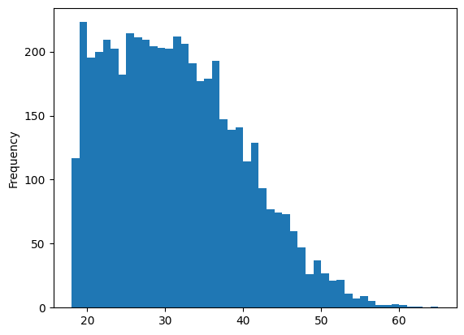

```python
df['age'].plot.hist(bins=47)
plt.show()
```

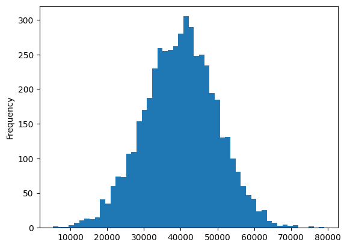

```python
df['salary'].plot.hist(bins=52)
plt.show()
```

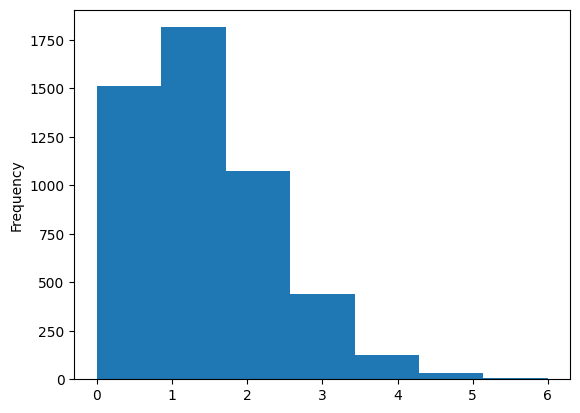

```python
df['family_members'].plot.hist(bins=7)
plt.show()
```

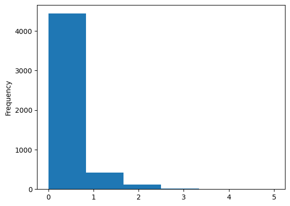

```python
df['insurance_payments'].plot.hist(bins=6)
plt.show()
```

#### Баланс классов

```python
df['insurance_payments'].value_counts(normalize=True)
```

```
0   0.89
1   0.08
2   0.02
3   0.00
4   0.00
5   0.00
Name: insurance_payments, dtype: float64
```

Классы несбалансированны. Так как задача прогнозирования - регрессия, дополнительных работ по балансировке данным не проводим.

#### Типы признаков

```python
features_int = df.drop(columns='insurance_payments').select_dtypes(include='number').columns.to_list()
features_cat = df.drop(columns='insurance_payments').select_dtypes(exclude='number').columns.to_list()
print(f'''Numerical: {features_int}
Categorical: {features_cat}''')
```

```
Numerical: ['gender', 'age', 'salary', 'family_members']
Categorical: []
```

Фактически мы имеем категории:

- gender
- family_members

Далее преобразуем в категориальные данные.

```python
df[['gender', 'family_members']] = df[['gender', 'family_members']].astype('category')
```

```python
features_int = df.drop(columns='insurance_payments').select_dtypes(include='number').columns.to_list()
features_cat = df.drop(columns='insurance_payments').select_dtypes(exclude='number').columns.to_list()
print(f'''Numerical: {features_int}
Categorical: {features_cat}''')
```

```
Numerical: ['age', 'salary']
Categorical: ['gender', 'family_members']
```

#### Влияние признаков на целевой признак

```python
df.groupby('gender')['insurance_payments'].agg(['count', 'mean'])
```

| gender | count | mean |
| --- | --- | --- |
| 0 | 2505 | 0.14 |
| 1 | 2495 | 0.15 |

Пол клиента не влияет на выплаты.

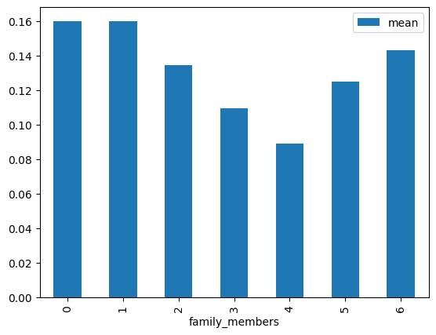

```python
df.groupby('family_members')['insurance_payments'].agg(['mean']).plot(kind='bar')
plt.show()
```

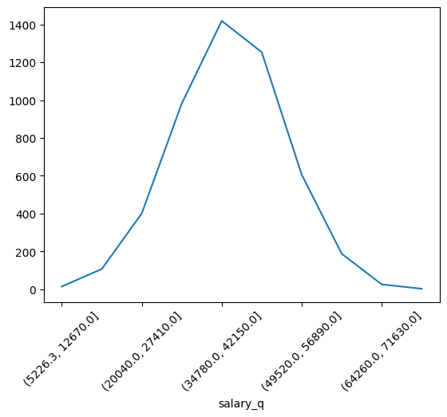

```python
df['salary_q'] = pd.cut(df['salary'], 10)
df.groupby('salary_q')['insurance_payments'].count().plot(rot=45)
plt.show()
```

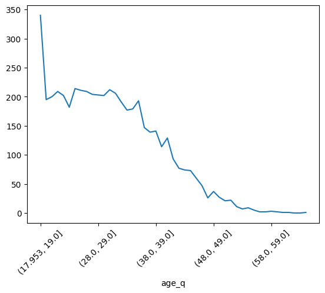

```python
df['age_q'] = pd.cut(df['age'], 47)
df.groupby('age_q')['insurance_payments'].count().plot(rot=45)
plt.show()
```

```python
df.groupby('age_q')['insurance_payments'].count()
```

```
age_q
(17.953, 19.0]    340
(19.0, 20.0]      195
(20.0, 21.0]      200
(21.0, 22.0]      209
(22.0, 23.0]      202
(23.0, 24.0]      182
(24.0, 25.0]      214
(25.0, 26.0]      211
(26.0, 27.0]      209
(27.0, 28.0]      204
(28.0, 29.0]      203
(29.0, 30.0]      202
(30.0, 31.0]      212
(31.0, 32.0]      206
(32.0, 33.0]      191
(33.0, 34.0]      177
(34.0, 35.0]      179
(35.0, 36.0]      193
(36.0, 37.0]      147
(37.0, 38.0]      139
(38.0, 39.0]      141
(39.0, 40.0]      114
(40.0, 41.0]      129
(41.0, 42.0]       93
(42.0, 43.0]       77
(43.0, 44.0]       74
(44.0, 45.0]       73
(45.0, 46.0]       60
(46.0, 47.0]       47
(47.0, 48.0]       26
(48.0, 49.0]       37
(49.0, 50.0]       27
(50.0, 51.0]       21
(51.0, 52.0]       22
(52.0, 53.0]       11
(53.0, 54.0]        7
(54.0, 55.0]        9
(55.0, 56.0]        5
(56.0, 57.0]        2
(57.0, 58.0]        2
(58.0, 59.0]        3
(59.0, 60.0]        2
(60.0, 61.0]        1
(61.0, 62.0]        1
(62.0, 63.0]        0
(63.0, 64.0]        0
(64.0, 65.0]        1
Name: insurance_payments, dtype: int64
```

```python
df[['age', 'insurance_payments']].describe()
```

|  | age | insurance_payments |
| --- | --- | --- |
| count | 5,000.00 | 5,000.00 |
| mean | 30.95 | 0.15 |
| std | 8.44 | 0.46 |
| min | 18.00 | 0.00 |
| 25% | 24.00 | 0.00 |
| 50% | 30.00 | 0.00 |
| 75% | 37.00 | 0.00 |
| max | 65.00 | 5.00 |

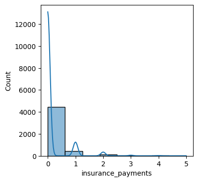

```python
# Визуализация распределения целевой переменной
plt.figure(figsize=(4, 4))
sns.histplot(data=df['insurance_payments'], bins=8, kde=True)
plt.show()
```

Количество обращений снижается. Данные представлены корректно.

```python
# Убираем вспомогательные столбцы
df = df.drop(columns=['salary_q', 'age_q'])
```

##### Корреляция

$\phi_K$

```python
phik_overview = df.phik_matrix()
```

```
interval columns not set, guessing: ['age', 'salary', 'insurance_payments']
```

```python
phik_overview
```

|  | gender | age | salary | family_members | insurance_payments |
| --- | --- | --- | --- | --- | --- |
| gender | 1.00 | 0.00 | 0.00 | 0.00 | 0.03 |
| age | 0.00 | 1.00 | 0.07 | 0.00 | 0.88 |
| salary | 0.00 | 0.07 | 1.00 | 0.00 | 0.00 |
| family_members | 0.00 | 0.00 | 0.00 | 1.00 | 0.00 |
| insurance_payments | 0.03 | 0.88 | 0.00 | 0.00 | 1.00 |

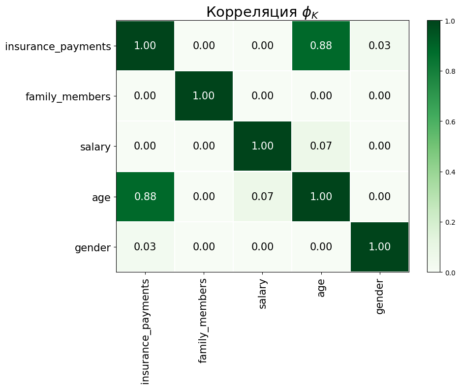

```python
plot_correlation_matrix(phik_overview.values,
                        x_labels=phik_overview.columns,
                        y_labels=phik_overview.index,
                        vmin=0, vmax=1, color_map="Greens",
                        title=r"Корреляция $\phi_K$",
                        fontsize_factor=1.5,
                        figsize=(10, 8))
plt.tight_layout()
```

```python
phik_overview['insurance_payments'].sort_values(ascending=False)
```

```
insurance_payments   1.00
age                  0.88
gender               0.03
salary               0.00
family_members       0.00
Name: insurance_payments, dtype: float64
```

Корреляция $\phi_K$ отображает сильную зависимость от возраста, и слабую зависимость от пола.

```python
df.info()
```

```
<class 'pandas.core.frame.DataFrame'>
RangeIndex: 5000 entries, 0 to 4999
Data columns (total 5 columns):
 #   Column              Non-Null Count  Dtype
---  ------              --------------  -----
 0   gender              5000 non-null   category
 1   age                 5000 non-null   float64
 2   salary              5000 non-null   float64
 3   family_members      5000 non-null   category
 4   insurance_payments  5000 non-null   int64
dtypes: category(2), float64(2), int64(1)
memory usage: 127.5 KB
```

## Умножение матриц

Обозначения:

- $X$ — матрица признаков (нулевой столбец состоит из единиц)
- $y$ — вектор целевого признака
- $P$ — матрица, на которую умножаются признаки
- $w$ — вектор весов линейной регрессии (нулевой элемент равен сдвигу)

Предсказания:

$$ a = Xw $$

Задача обучения:

$$ w = \arg\min_w MSE(Xw, y) $$

Формула обучения:

$$ w = (X^T X)^{-1} X^T y $$

**Ответ:** Качество линейной регрессии при умножении признаков на обратимую матрицу не изменится.

**Обоснование:** Представим новую матрицу признаков X1 как произведение старой X на матрицу P(обратимую): $$X1 = X∗P$$ Подставим новое значение X1 в формулу w1: $$w1=((XP)^TXP)^{−1}(XP)^Ty$$ Раскроем первое произведение (XP)^T: $$w1=(P^TX^TXP)^{-1}P^TX^Ty$$ Перегруппируем множители в скобках, чтобы это выглядело как произведение трех множителей: $$w1=(P^T(X^TX)P)^{-1}P^TX^Ty$$ Раскроем скобки $(P^T(X^TX)P)^{-1}$ : $$w1=P^{-1}(X^TX)^{-1}(P^T)^{-1}P^TX^Ty$$ Так как $P$ по условию обратимая, то произведение $(P^T)^{−1}P^T$ равно $E$(единичная матрица): $$w1=P^{-1}(X^TX)^{-1}EX^Ty=P^{-1}(X^TX)^{-1}X^Ty$$ Можно заметить, что справа получилась формула для $w$: $$w1=P^{-1}(X^TX)^{-1}X^Ty=P^{-1}w$$ Подставим новое значение весов $𝑤1$ в формулу для предсказаний линейной регрессии. Предсказания модели расчитываются по формуле: $$a=Xw$$ Подставим в эту формулу значения $X1$ и $w1$ для того, чтобы на их основе вычислить предсказания модели $a1$: $$a1=X1w1=XPP^{-1}w$$ Так как $P$ по условию обратимая, то произведение $PP^{−1}$ снова равно $E$: $$a1=XPP^{-1}w=XEw=Xw=a$$ Мы доказали, что предсказания $a1$ для матрицы признаков, умноженных на обратимую матрицу $P$ равны предсказаниям $a$. В данном случае, параметры линейной регрессии в исходной задаче $w$ и в преобразованной $w1$ связаны следующим образом: $$w1=P^{-1}w$$

## Алгоритм преобразования

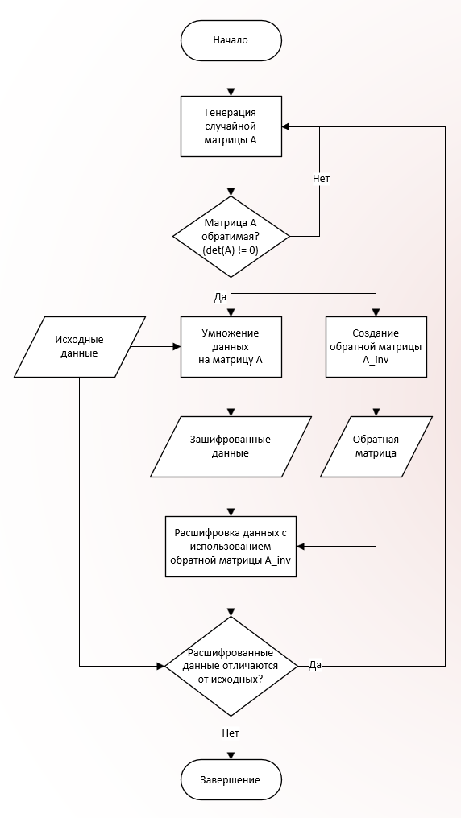

### Разбивка датасета на наборы данных

```python
def data_split(datasets,
               test_sets=False,
               train_size=0.7,
               valid_size=0.3,
               target_name='',
               random_state=RANDOM_STATE):
    '''Функция делит датасеты на выборки:
        - обучающая
        - валидационная
        - тестовая

    Args:
        datasets: (array) Массив датасетов
        test_sets: (bool) Необходима ли тестовая выборк, по умолчанию False
        train_size: (float) Размер доли обучающей выборки, по умолчанию 0.7
        valid_size: (float) Размер доли валидационной выборки, по умолчанию 0.3. Этим параметром управляется размер тестовой выборки по остаточному принципу
        target_name: (string) Наименование столбца целевого признака
        random_state: (int or object numpy random_stat)

    Returns:
        array: Упакованные массивы с выборками.'''

    datasets_jointed = []

    if ((round(train_size + valid_size, 2) == 1) & (test_sets == True)) | ((train_size + valid_size) != 1.0) & (test_sets == False):
        print('Проверь размер датасетов ')
    else:
        if test_sets == False:
            for set in datasets:
                print(f'___________________________')
                target_all = set[target_name]
                features_all = set.drop(target_name, axis=1)

                features_train, features_valid, target_train, target_valid = train_test_split(
                    features_all, target_all, test_size=valid_size, train_size=train_size, random_state=random_state)

                print(f'target_train размер: {len(target_train) / len(target_all) * 100:.0f}%')
                print(f'target_valid размер: {len(target_valid) / len(target_all) * 100:.0f}%')
                display(features_train.head())
                datasets_jointed.append([features_train, features_valid, target_train, target_valid])
        else:
            for set in datasets:
                print(f'___________________________')
                target_all = set[target_name]
                features_all = set.drop(target_name, axis=1)

                test_s = round(1 - train_size - valid_size, 2)
                valid_size_prop = round(valid_size / (train_size + valid_size), 2)

                features, features_test, target, target_test = train_test_split(
                    features_all, target_all, test_size=test_s, train_size=1-test_s, random_state=RANDOM_STATE
                )
                features_train, features_valid, target_train, target_valid = train_test_split(
                    features, target, test_size=valid_size_prop, train_size=1-valid_size_prop, random_state=RANDOM_STATE
                )

                print(f'target: {target_name}')
                print(f'target_train размер: {len(target_train) / len(target_all) * 100:.0f}%')
                print(f'target_valid размер: {len(target_valid) / len(target_all) * 100:.0f}%')
                print(f'target_test размер: {len(target_test) / len(target_all) * 100:.0f}%')
                display(features_train.head())
                datasets_jointed.append([features_train, features_valid, features_test, target_train, target_valid, target_test])
    return datasets_jointed
```

```python
# Разбивка на выборки
datasets = data_split([df],
               train_size=0.75,
               valid_size=0.25,
               target_name='insurance_payments')
```

```
___________________________
target_train размер: 75%
target_valid размер: 25%
```

|  | gender | age | salary | family_members |
| --- | --- | --- | --- | --- |
| 4621 | 0 | 22.00 | 20,800.00 | 1 |
| 2690 | 0 | 35.00 | 46,300.00 | 1 |
| 2068 | 0 | 38.00 | 44,200.00 | 3 |
| 1191 | 1 | 31.00 | 45,100.00 | 0 |
| 2066 | 0 | 19.00 | 40,100.00 | 1 |

```python
features_train = datasets[0][0]
features_test = datasets[0][1]
target_train = datasets[0][2]
target_test = datasets[0][3]

del datasets
```

### Преобразование наборов данных в матрицы

Библиотека Numpy работает с матрицами, и при помощи этой библиотеки можно проводить любые преобразования матриц. Переходим от использования Pandas к Numpy.

```python
features_train_matrix = features_train.values
features_test_matrix = features_test.values

print(features_train_matrix.shape)
print(features_test_matrix.shape)
```

```
(3750, 4)
(1250, 4)
```

### Рандомная обратимая матрица

```python
def get_rand_matrix(data):
    det = 0
    while det == 0:
        matrix = np.random.normal(size=(data.shape[1], data.shape[1]))
        det = np.linalg.det(matrix)
    return matrix
```

```python
random_matrix = get_rand_matrix(features_train_matrix)
random_matrix
```

```
array([[-0.53128277, -0.730526  , -0.68722756,  0.77374335],
       [ 1.03311863,  0.30379555, -0.83870652, -0.41860281],
       [-1.77840425, -0.20166098,  1.80923041,  0.60664429],
       [ 0.63651104, -0.46516213,  0.9706266 ,  1.0959    ]])
```

Проверка на обратимость. Произведение матрицы на её обратную должно дать в результате единичную матрицу, а именно:

- Заполнение нолями
- Заполнение единицами по главной диагонали

```python
np.round(random_matrix @ np.linalg.inv(random_matrix))
```

```
array([[ 1., -0.,  0.,  0.],
       [-0.,  1., -0., -0.],
       [ 0.,  0.,  1., -0.],
       [ 0.,  0.,  0.,  1.]])
```

### Кодирование и декодирование

```python
# Кодирование выполняем произведением матриц
features_train_matrix_encoded = features_train_matrix @ random_matrix
features_test_matrix_encoded = features_test_matrix @ random_matrix
```

```python
# Проверка закодированных данных
features_train_matrix_encoded
```

```
array([[-36967.44323304,  -4188.33008028,  37614.51169199,
         12610.08777881],
       [-82303.32100937,  -9326.73577261,  83738.98406128,
         28074.07522532],
       [-78564.29971105,  -8903.26664855,  79939.02532578,
         26801.05821709],
       ...,
       [-54562.81226396,  -6182.16257448,  55515.97979018,
         18612.03531876],
       [-75028.5281667 ,  -8504.74804461,  76332.06210794,
         25592.79053987],
       [-65944.99605737,  -7473.56181534,  67096.86377215,
         22496.07324948]])
```

Данные успешно закодированы, персональные данные под защитой.

```python
# Декодируем
features_train_matrix_decoded = (features_train_matrix_encoded
                                 @ np.linalg.inv(random_matrix))

# Округление до целых после математических преобразований
features_train_matrix_decoded = np.abs(np.round(features_train_matrix_decoded))

# Возвращаем к представлению исходного датасета
features_train_decoded = pd.DataFrame(
    features_train_matrix_decoded,
    columns=features_train.columns,
    index=features_train.index
)
features_train_decoded[['gender', 'family_members']] = features_train_decoded[['gender', 'family_members']].astype('category')
```

### Контрольные показатели выборок "До" и "После" кодирования

```python
display(features_train.describe(include='all'))
display(features_train_decoded.describe(include='all'))
```

|  | gender | age | salary | family_members |
| --- | --- | --- | --- | --- |
| count | 3,750.00 | 3,750.00 | 3,750.00 | 3,750.00 |
| unique | 2.00 | NaN | NaN | 7.00 |
| top | 0.00 | NaN | NaN | 1.00 |
| freq | 1,876.00 | NaN | NaN | 1,384.00 |
| mean | NaN | 30.97 | 39,795.55 | NaN |
| std | NaN | 8.47 | 9,917.24 | NaN |
| min | NaN | 18.00 | 5,300.00 | NaN |
| 25% | NaN | 24.00 | 33,100.00 | NaN |
| 50% | NaN | 30.00 | 40,000.00 | NaN |
| 75% | NaN | 37.00 | 46,500.00 | NaN |
| max | NaN | 65.00 | 79,000.00 | NaN |

|  | gender | age | salary | family_members |
| --- | --- | --- | --- | --- |
| count | 3,750.00 | 3,750.00 | 3,750.00 | 3,750.00 |
| unique | 2.00 | NaN | NaN | 7.00 |
| top | 0.00 | NaN | NaN | 1.00 |
| freq | 1,876.00 | NaN | NaN | 1,384.00 |
| mean | NaN | 30.97 | 39,795.55 | NaN |
| std | NaN | 8.47 | 9,917.24 | NaN |
| min | NaN | 18.00 | 5,300.00 | NaN |
| 25% | NaN | 24.00 | 33,100.00 | NaN |
| 50% | NaN | 30.00 | 40,000.00 | NaN |
| 75% | NaN | 37.00 | 46,500.00 | NaN |
| max | NaN | 65.00 | 79,000.00 | NaN |

```python
display(features_train.head(10))
display(features_train_decoded.head(10))
```

|  | gender | age | salary | family_members |
| --- | --- | --- | --- | --- |
| 4621 | 0 | 22.00 | 20,800.00 | 1 |
| 2690 | 0 | 35.00 | 46,300.00 | 1 |
| 2068 | 0 | 38.00 | 44,200.00 | 3 |
| 1191 | 1 | 31.00 | 45,100.00 | 0 |
| 2066 | 0 | 19.00 | 40,100.00 | 1 |
| 470 | 1 | 35.00 | 40,100.00 | 4 |
| 3015 | 1 | 31.00 | 35,700.00 | 0 |
| 1858 | 0 | 31.00 | 35,600.00 | 0 |
| 1359 | 0 | 36.00 | 43,900.00 | 0 |
| 4815 | 1 | 19.00 | 32,400.00 | 0 |

|  | gender | age | salary | family_members |
| --- | --- | --- | --- | --- |
| 4621 | 0.00 | 22.00 | 20,800.00 | 1.00 |
| 2690 | 0.00 | 35.00 | 46,300.00 | 1.00 |
| 2068 | 0.00 | 38.00 | 44,200.00 | 3.00 |
| 1191 | 1.00 | 31.00 | 45,100.00 | 0.00 |
| 2066 | 0.00 | 19.00 | 40,100.00 | 1.00 |
| 470 | 1.00 | 35.00 | 40,100.00 | 4.00 |
| 3015 | 1.00 | 31.00 | 35,700.00 | 0.00 |
| 1858 | 0.00 | 31.00 | 35,600.00 | 0.00 |
| 1359 | 0.00 | 36.00 | 43,900.00 | 0.00 |
| 4815 | 1.00 | 19.00 | 32,400.00 | 0.00 |

### Вывод

Алгоритм преобразования работает в обе стороны. Данные восстанавливаются без потерь.

## Проверка алгоритма

Проверим алгоритм на разных данных - до и после кодирования. Сравним оценку метрики R2.

```python
model = LinearRegression()
```

```python
# Некодированные данные
model.fit(features_train_matrix, target_train)
predicted_norm = model.predict(features_test_matrix)
r2 = model.score(features_test_matrix, target_test)

print('Оценка R2 некодированной матрицы: ', r2)
```

```
Оценка R2 некодированной матрицы:  0.4203943570738201
```

```python
# Кодированные данные
model.fit(features_train_matrix_encoded, target_train)
predicted_norm = model.predict(features_test_matrix_encoded)
r2_encoded = model.score(features_test_matrix_encoded, target_test)

print('Оценка R2 кодированной матрицы: ', r2_encoded)
```

```
Оценка R2 кодированной матрицы:  0.42039435707466355
```

```python
r2 - r2_encoded
```

```
-8.434364318077314e-13
```

Показатели метрик почти не имеют различий. Качество модели при разработанном алгоритме не падает.

## Общий вывод

Для защиты данных был использован алгоритм кодирования данных. Алгоритм основан на:

- свойствах произведения матриц
- свойствах обратной матрицы

Произведены проверки работы алгоритма:

- Восстановление закодированных данных (декодирование)
- Измерение метрики модели R2 на исходных и закодированных данных

Проверки прошли успешно, алгоритм рабочий.